# Red Wine Quality Analysis

The dataset was created using red wine samples. The inputs include objective tests (e.g. PH values) and the output is based on sensory data (median of at least 3 evaluations made by wine experts). Each expert graded the wine quality between 0 (very bad) and 10 (very excellent).

The dataset is related to red variants of the Portuguese “Vinho Verde” wine. Due to privacy and logistic issues, only physicochemical (inputs) and sensory (the output) variables are available (e.g. there is no data about grape types, wine brand, wine selling price, etc.).

```
## 'data.frame':    1599 obs. of  13 variables:
##  $ X                   : int  1 2 3 4 5 6 7 8 9 10 ...
##  $ fixed.acidity       : num  7.4 7.8 7.8 11.2 7.4 7.4 7.9 7.3 7.8 7.5 ...
##  $ volatile.acidity    : num  0.7 0.88 0.76 0.28 0.7 0.66 0.6 0.65 0.58 0.5 ...
##  $ citric.acid         : num  0 0 0.04 0.56 0 0 0.06 0 0.02 0.36 ...
##  $ residual.sugar      : num  1.9 2.6 2.3 1.9 1.9 1.8 1.6 1.2 2 6.1 ...
##  $ chlorides           : num  0.076 0.098 0.092 0.075 0.076 0.075 0.069 0.065 0.073 0.071 ...
##  $ free.sulfur.dioxide : num  11 25 15 17 11 13 15 15 9 17 ...
##  $ total.sulfur.dioxide: num  34 67 54 60 34 40 59 21 18 102 ...
##  $ density             : num  0.998 0.997 0.997 0.998 0.998 ...
##  $ pH                  : num  3.51 3.2 3.26 3.16 3.51 3.51 3.3 3.39 3.36 3.35 ...
##  $ sulphates           : num  0.56 0.68 0.65 0.58 0.56 0.56 0.46 0.47 0.57 0.8 ...
##  $ alcohol             : num  9.4 9.8 9.8 9.8 9.4 9.4 9.4 10 9.5 10.5 ...
##  $ quality             : int  5 5 5 6 5 5 5 7 7 5 ...
```

```
##        X        fixed.acidity   volatile.acidity  citric.acid
##  1      :   1   Min.   : 4.60   Min.   :0.1200   Min.   :0.000
##  2      :   1   1st Qu.: 7.10   1st Qu.:0.3900   1st Qu.:0.090
##  3      :   1   Median : 7.90   Median :0.5200   Median :0.260
##  4      :   1   Mean   : 8.32   Mean   :0.5278   Mean   :0.271
##  5      :   1   3rd Qu.: 9.20   3rd Qu.:0.6400   3rd Qu.:0.420
##  6      :   1   Max.   :15.90   Max.   :1.5800   Max.   :1.000
##  (Other):1593
##  residual.sugar     chlorides       free.sulfur.dioxide
##  Min.   : 0.900   Min.   :0.01200   Min.   : 1.00
##  1st Qu.: 1.900   1st Qu.:0.07000   1st Qu.: 7.00
##  Median : 2.200   Median :0.07900   Median :14.00
##  Mean   : 2.539   Mean   :0.08747   Mean   :15.87
##  3rd Qu.: 2.600   3rd Qu.:0.09000   3rd Qu.:21.00
##  Max.   :15.500   Max.   :0.61100   Max.   :72.00
##
##  total.sulfur.dioxide    density             pH          sulphates
##  Min.   :  6.00       Min.   :0.9901   Min.   :2.740   Min.   :0.3300
##  1st Qu.: 22.00       1st Qu.:0.9956   1st Qu.:3.210   1st Qu.:0.5500
##  Median : 38.00       Median :0.9968   Median :3.310   Median :0.6200
##  Mean   : 46.47       Mean   :0.9967   Mean   :3.311   Mean   :0.6581
##  3rd Qu.: 62.00       3rd Qu.:0.9978   3rd Qu.:3.400   3rd Qu.:0.7300
##  Max.   :289.00       Max.   :1.0037   Max.   :4.010   Max.   :2.0000
##
##     alcohol         quality
##  Min.   : 8.40   Min.   :3.000
##  1st Qu.: 9.50   1st Qu.:5.000
##  Median :10.20   Median :6.000
##  Mean   :10.42   Mean   :5.636
##  3rd Qu.:11.10   3rd Qu.:6.000
##  Max.   :14.90   Max.   :8.000
##
```

# Univariate Plots Section

In this section we will look at different variables individually

## Quality

```
##    Min. 1st Qu.  Median    Mean 3rd Qu.    Max.
##   3.000   5.000   6.000   5.636   6.000   8.000
```

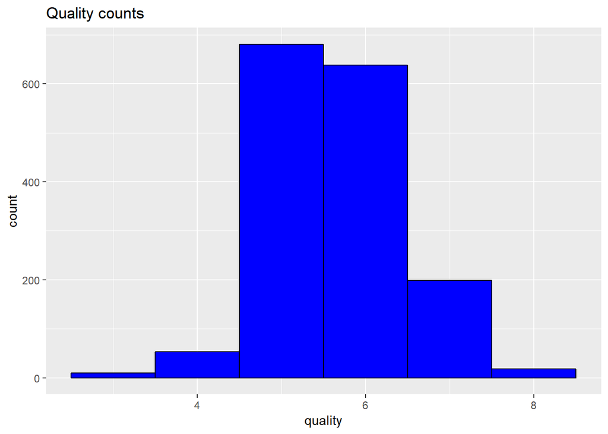

Here we see in this graph that we have more observations for the normal wine than for poor and good quality.

## Fixed Acidity (Nonvolatile acids)

```
##    Min. 1st Qu.  Median    Mean 3rd Qu.    Max.
##    4.60    7.10    7.90    8.32    9.20   15.90
```

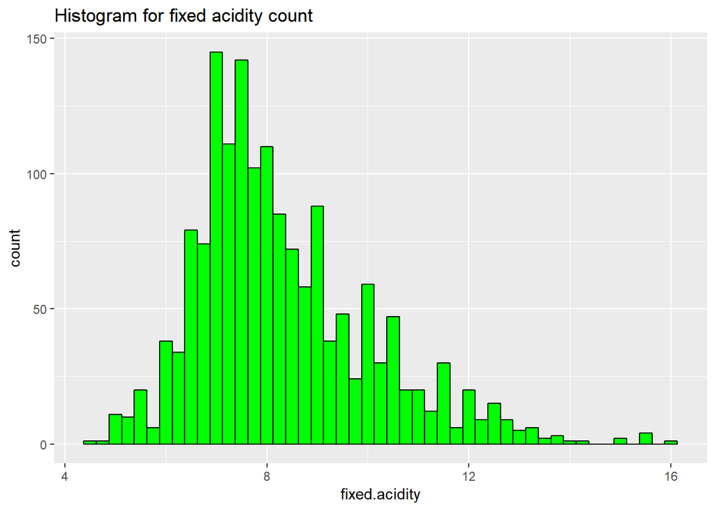

The data is skewed. The values are more concentrated towards the left. With a few outliers near 15 and 16.

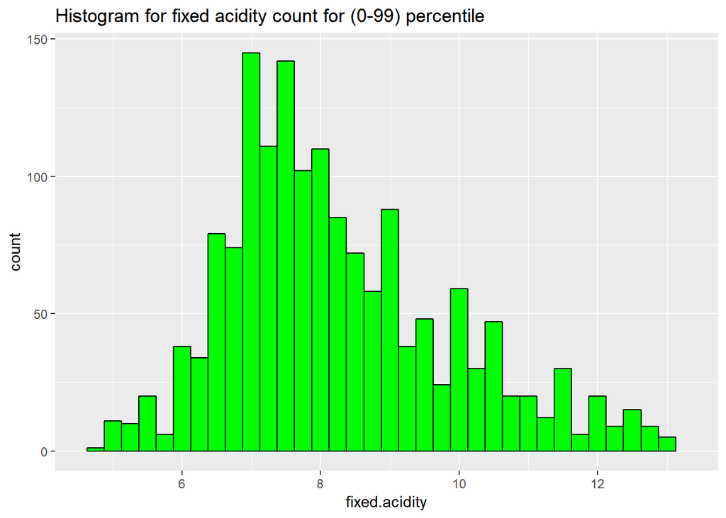

In this graph we removed the upper 1% of values. and now the graphed is less skewed.

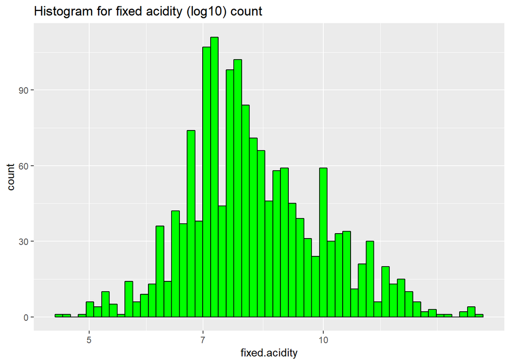

This graphs is for log10 tranformation of data and seem more normal without removing the outliers. We have max values between 7 and 8.5 approx and then on max value at 10.

## Volatile acidity (Acetic acid)

```
##    Min. 1st Qu.  Median    Mean 3rd Qu.    Max.
##  0.1200  0.3900  0.5200  0.5278  0.6400  1.5800
```

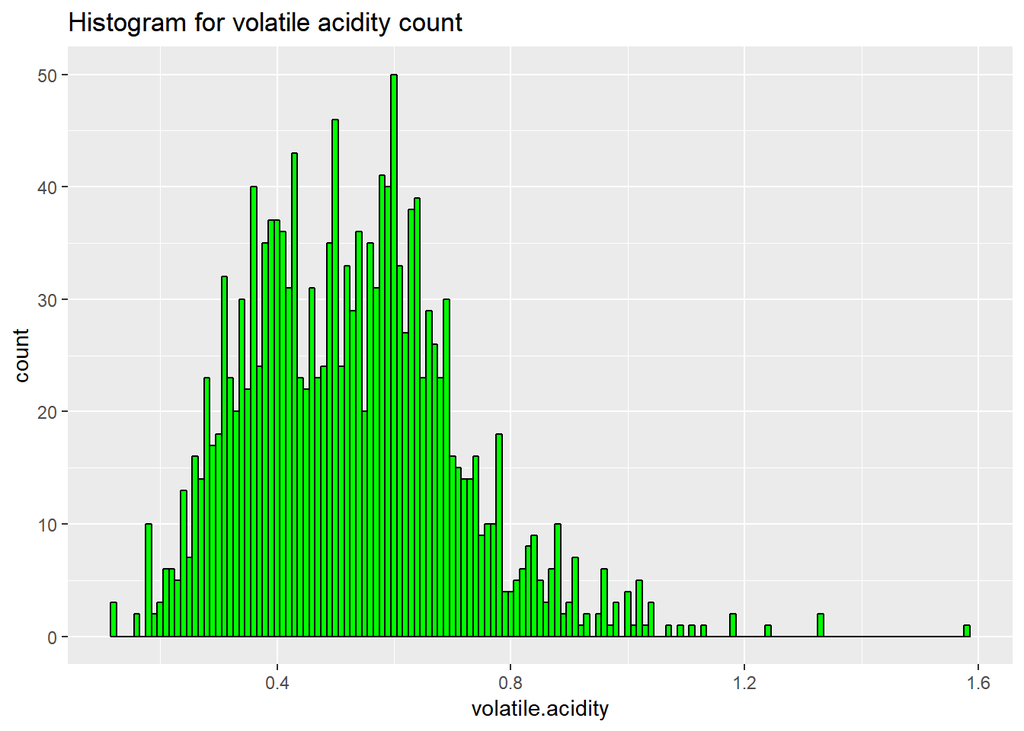

This is the histogram for volatile acidity count. We can see a few outliers on both tails, with min val of 0.12 and max of 1.58 There are gaps on both end and these values seems to be outliers, specially on the right tail.

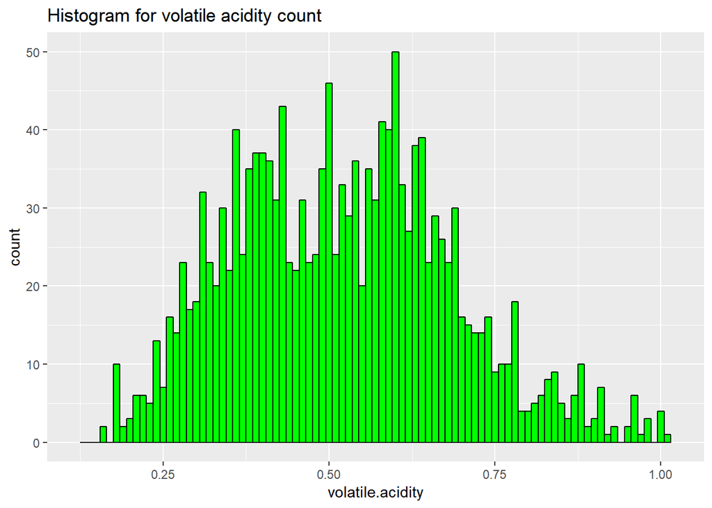

After removing the upper 1% values graph is more clear with some spikes at around 0.40, 0.50 and 0.60

## Citric acid

```
##    Min. 1st Qu.  Median    Mean 3rd Qu.    Max.
##   0.000   0.090   0.260   0.271   0.420   1.000
```

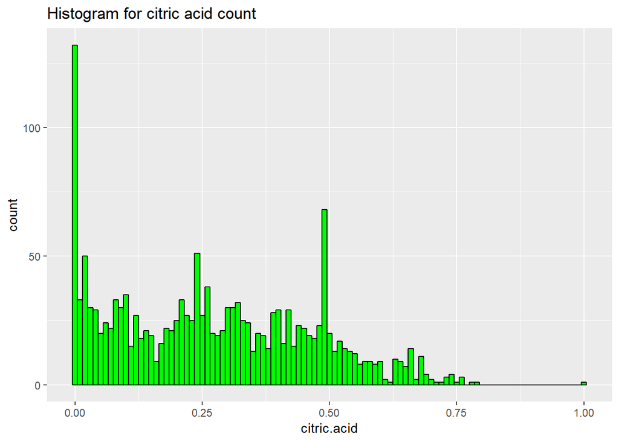

This is interesting we have values between 0 and 1. with max values at 0 and then we see a high number for 0.50 and a very slight rise at 0.25 We see that 75% is at 0.42, that is less than half of the range of values.

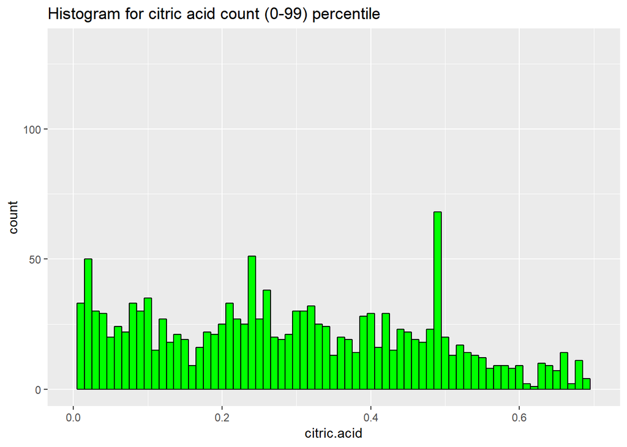

## Residual sugar

```
##    Min. 1st Qu.  Median    Mean 3rd Qu.    Max.
##   0.900   1.900   2.200   2.539   2.600  15.500
```

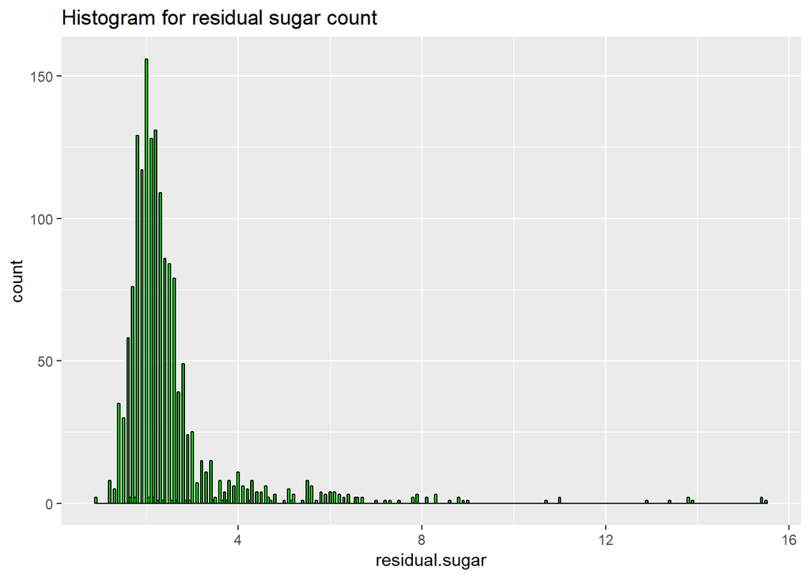

The data is very much normal with a long tail towards the right

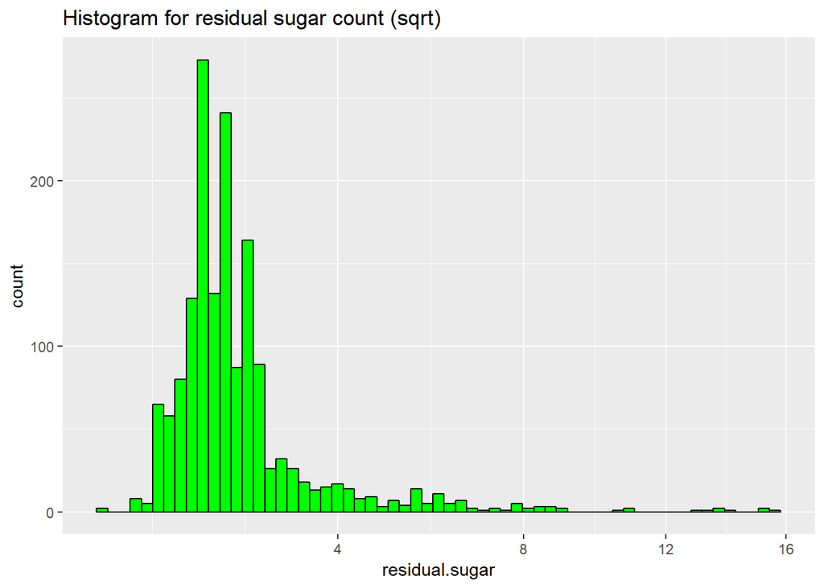

With sqrt it is still concentrated to the left

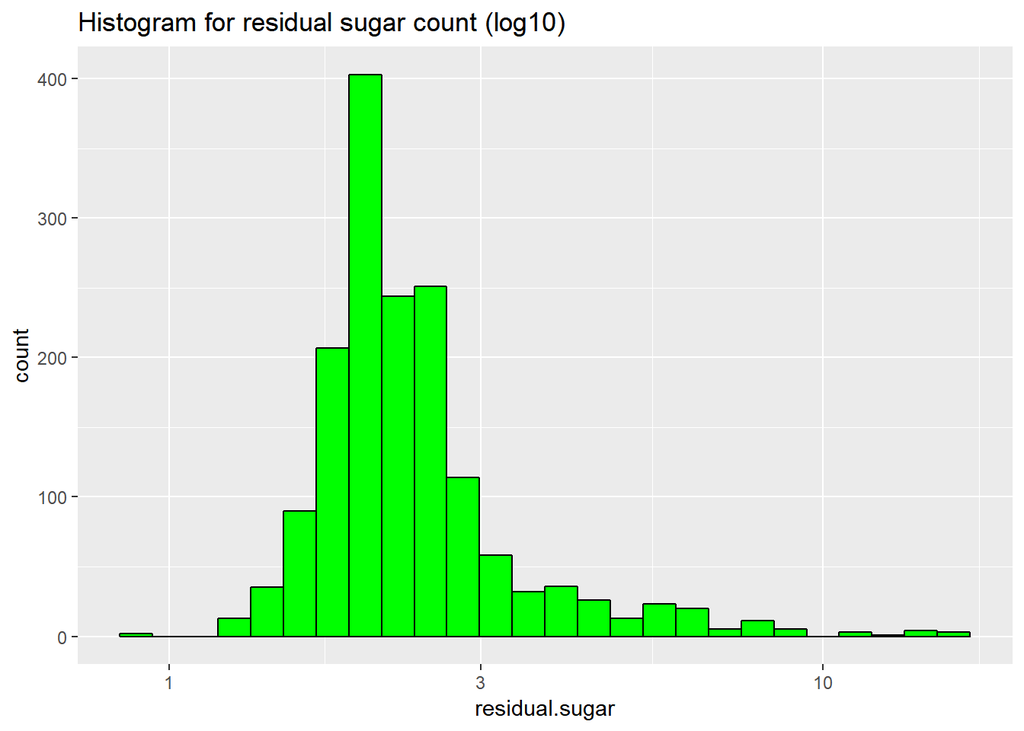

We can see with log10 transformation that we have high count for approx 2.2

## Chlorides (Salt)

```
##    Min. 1st Qu.  Median    Mean 3rd Qu.    Max.
## 0.01200 0.07000 0.07900 0.08747 0.09000 0.61100
```

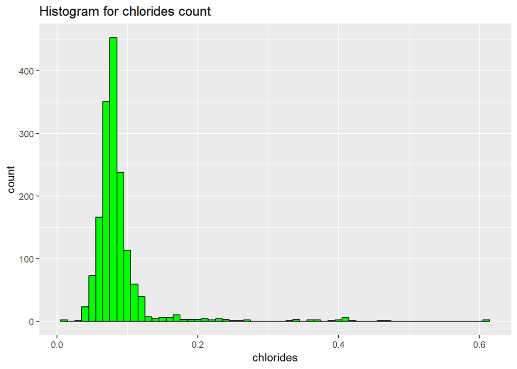

this data has similar shape to sugar residue data

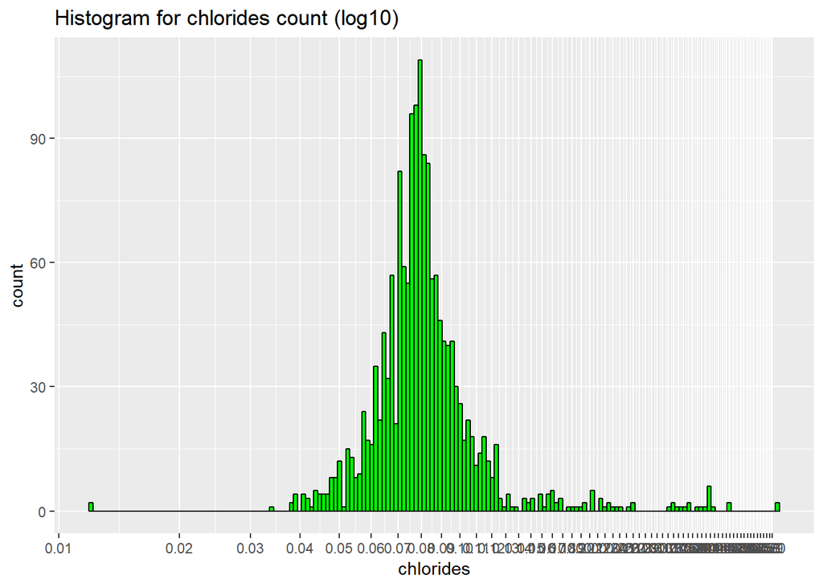

So we have a clear spike at 0.08 and very clear outliers near 0.01 and 0.6

## Sulfur dioxides and Sulphates

```
##    Min. 1st Qu.  Median    Mean 3rd Qu.    Max.
##    1.00    7.00   14.00   15.87   21.00   72.00
```

```
##    Min. 1st Qu.  Median    Mean 3rd Qu.    Max.
##    6.00   22.00   38.00   46.47   62.00  289.00
```

```
##    Min. 1st Qu.  Median    Mean 3rd Qu.    Max.
##  0.3300  0.5500  0.6200  0.6581  0.7300  2.0000
```

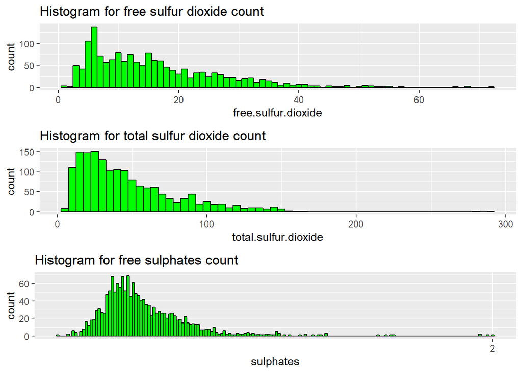

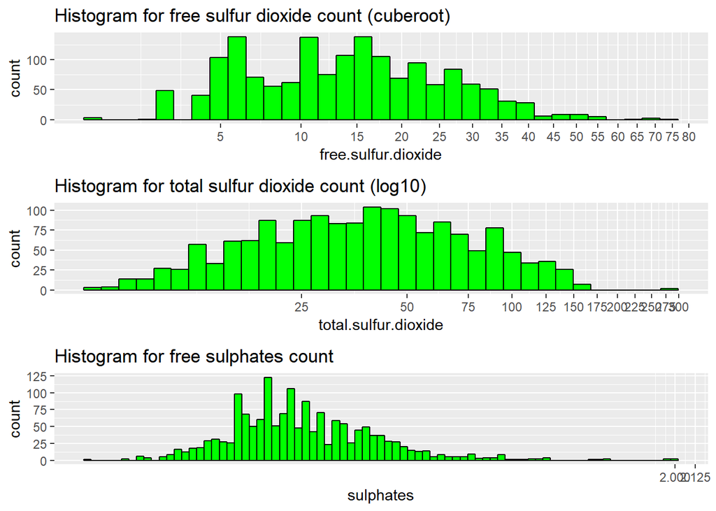

In these graphs we have the cuberoot of free sulfur dioxide, log10 oftotal sulfur dioxide and again cuberoot of sulphates

## Density

```
##    Min. 1st Qu.  Median    Mean 3rd Qu.    Max.
##  0.9901  0.9956  0.9968  0.9967  0.9978  1.0037
```

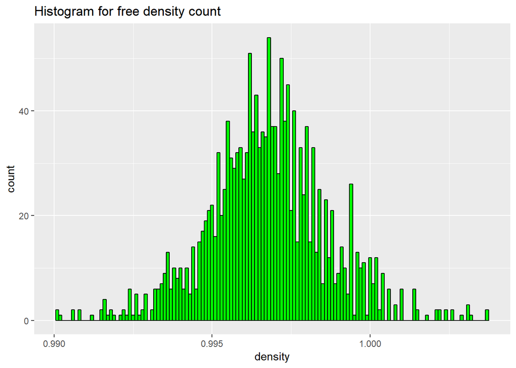

The density values are very small but the data seems normally distributed.

## pH

```
##    Min. 1st Qu.  Median    Mean 3rd Qu.    Max.
##   2.740   3.210   3.310   3.311   3.400   4.010
```

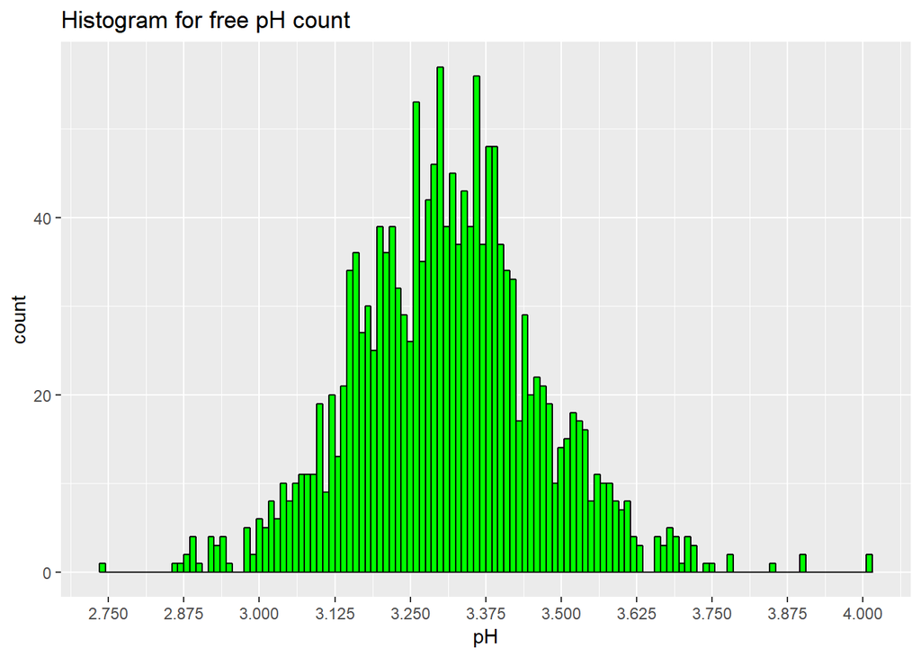

Same goes for our pH index.

# Univariate Analysis

### What is the structure of your dataset?

We have 1599 observations and 12 features in our data

All the test values are continuous, with varing ranges and the output quality is a scale: 0 ——-> 10 (Worst) (Best)

The dataset is biased as there are more observations for normal quality as for the good and poor ones. Interesting thing is the scale for quality is 0-10 but the min-max values for data are 3-8, no wine is very bad and none is exceptionally good.

### What is/are the main feature(s) of interest in your dataset?

The main feature is the quality of wine. I’d like to determine what determines the quality of a wine.

### What other features in the dataset do you think will help support your

investigation into your feature(s) of interest?

The acids in our dataset and suger and salt(chloride) are the more likely candidates for the wine quality from what I understand about wines. the pH may depend upon the concentration of acids and the density on sugar content.

### Did you create any new variables from existing variables in the dataset?

No I didn’t create new variables.

### Of the features you investigated, were there any unusual distributions?

Did you perform any operations on the data to tidy, adjust, or change the form  
of the data? If so, why did you do this?

Most of the distributions were skewed with outliers towards max values. I log10, sqrt and cuberoot transformed or removed upper 1% values to plot in these distribuions. We know that we have very few good and poor wines. These outlier values may be related to these observations, which I would like to explore more in the next sections.

# Bivariate Plots Section

In this section we are going to look at pairs of features, how they are related to one another.

## Fixed acidity and Citic Acid vs Quality

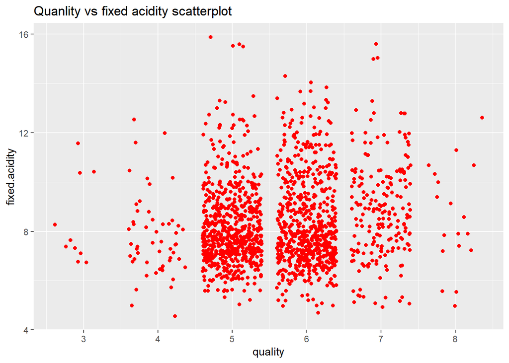

In this acidity vs quality section we see that the acidic quantity is more in normal wine and we know that we have more observations for normal wines, which may produce this bias

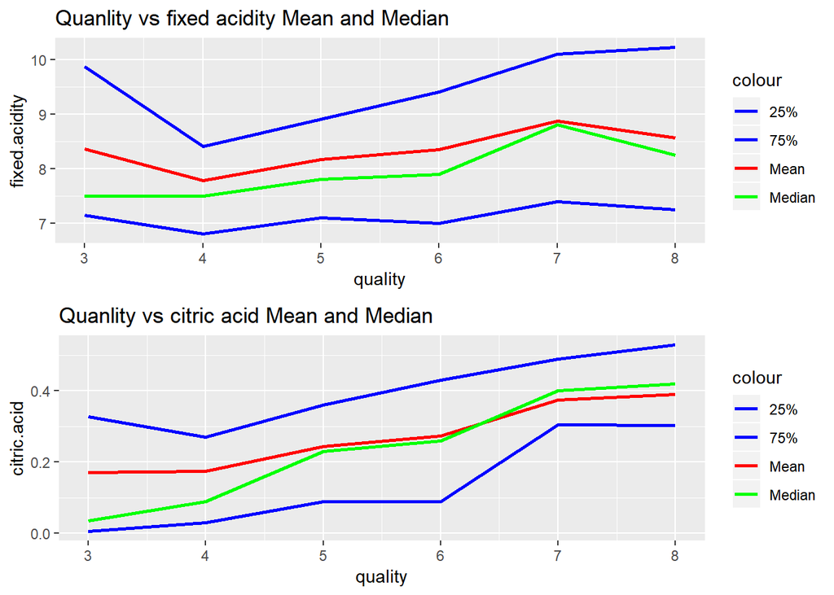

Here we see that as the fixed acidity increses as the quality increases but after quality level 7 there is a fall in acidity.

In second graph it shows an upward trend in citric acid with the quality of wine, the more citric flavour the better the wine. This trend is similar to fixed acidity trend.

## Volatile acidity vs Quality

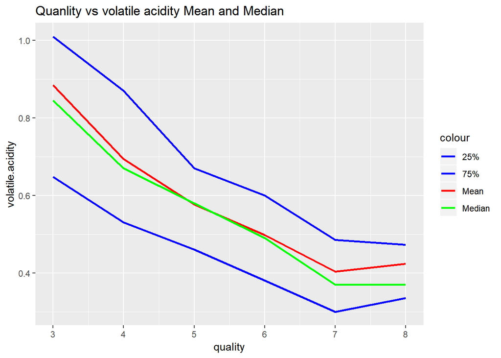

We see a downwards trend in acidity as the quality increases and at level 8 the meadian value is same as level same other values show a slight increase

## Residual sugar vs Quality

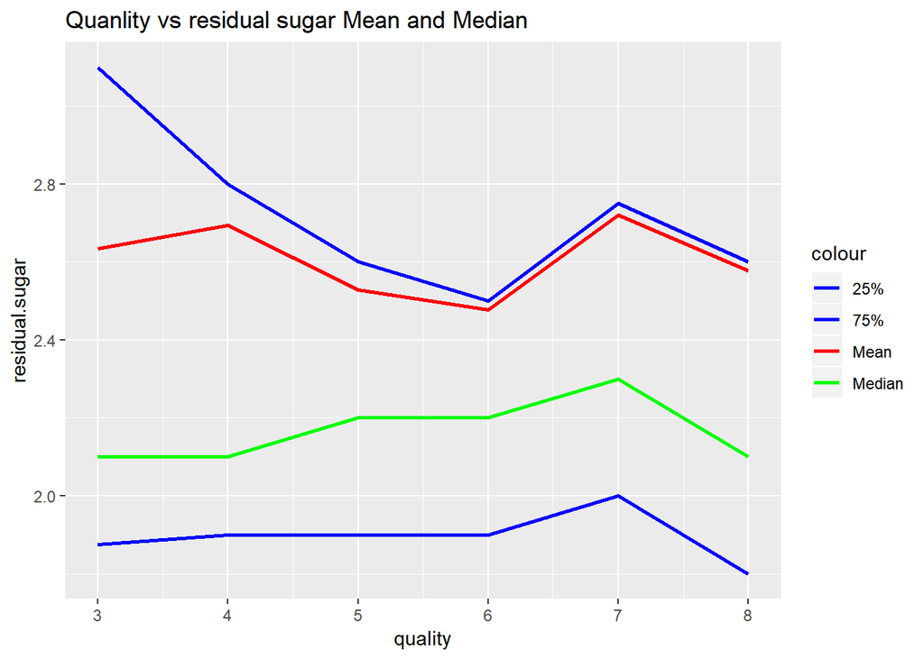

## Chlorides vs Quality

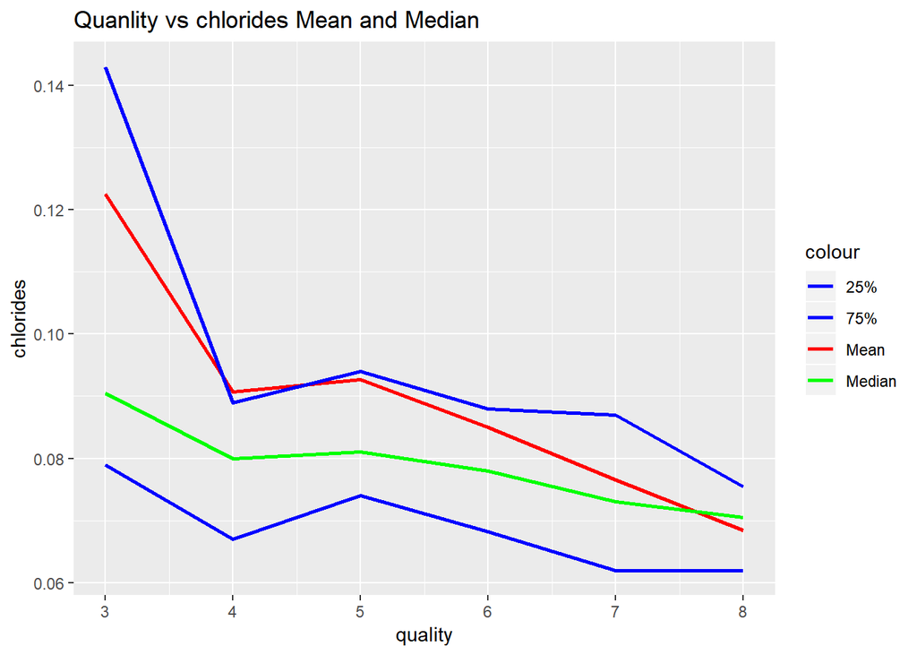

## Sulfur dioxides vs Quality

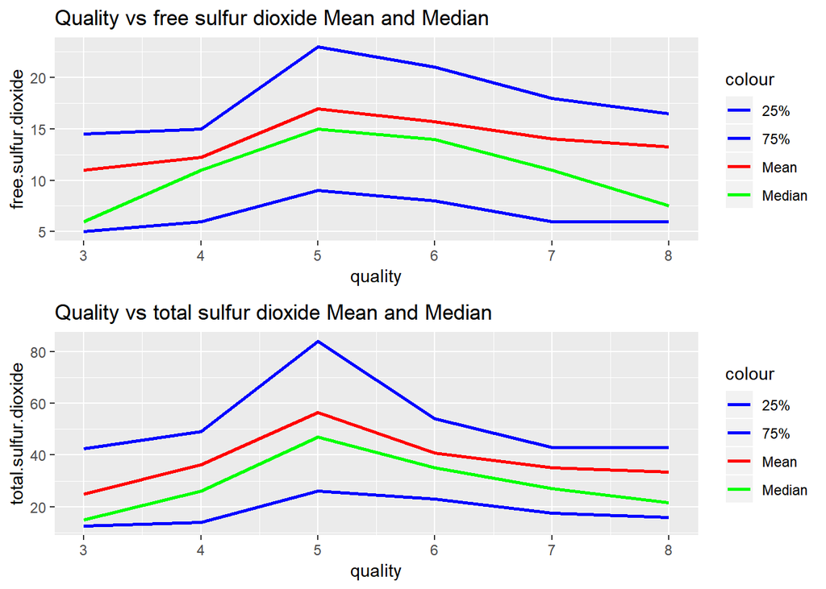

We see a similar trend in both values with respect to qaulity because total sulfur dioxide is sum of both free and bound sulfur dioxides. For normal wines the value is high and for both poor and good wines the value is low

## Sulphates vs Quality

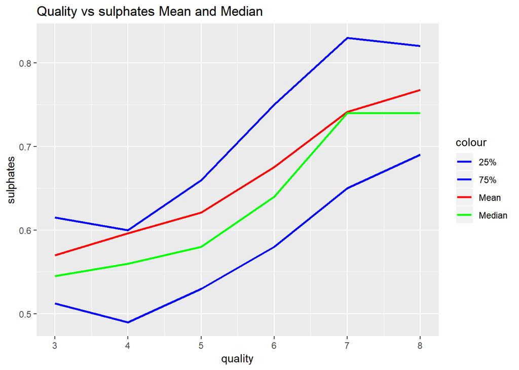

This shows a positive relation between sulphates and quality

## pH vs Quality

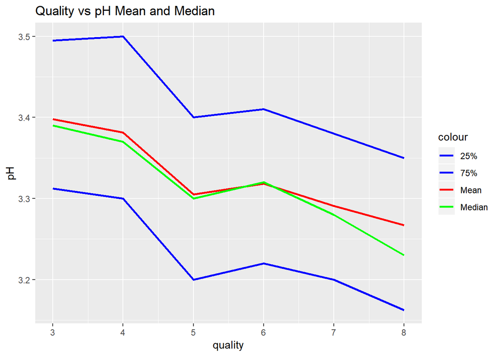

For poor wines the pH level is high but for good wines the pH level is low. Low pH levels cooresponds to more acidity. This represents the overall acidity of our wine.

## Alcohol vs Quality

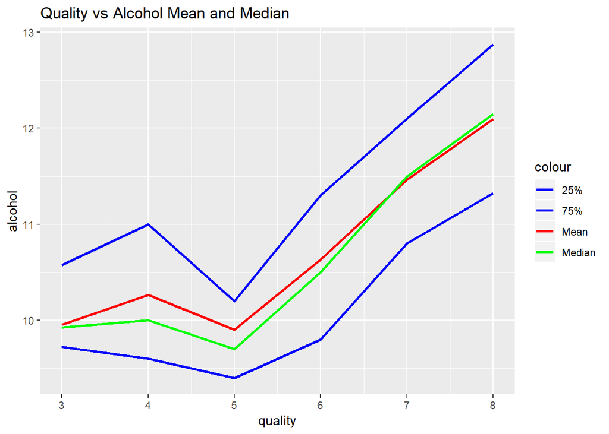

This is again a upwards trend. The quality is getting better with the alcohol content

## Density vs quality

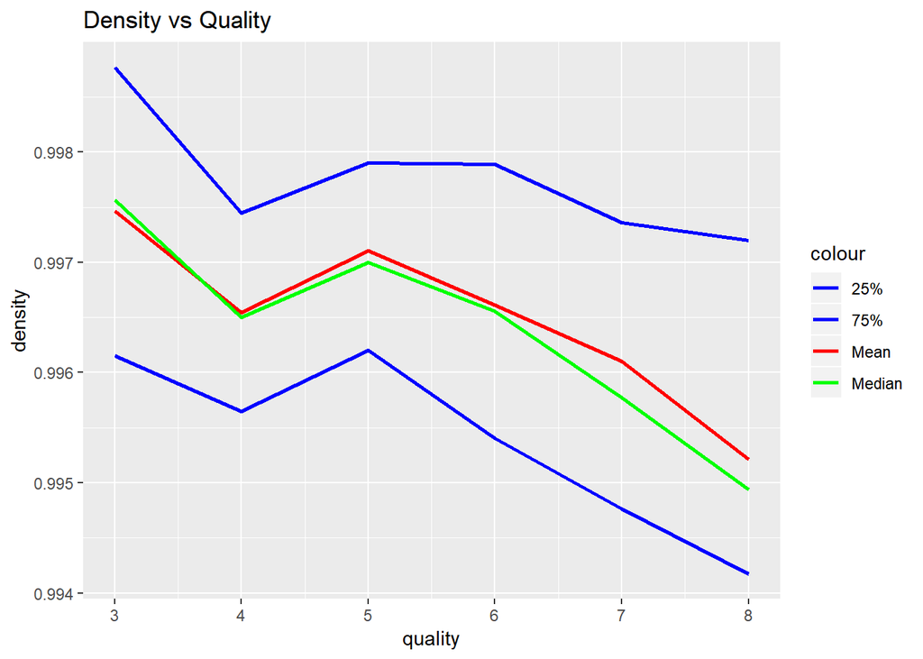

This shows a low density for good wines

## Acids, Sugar and salt

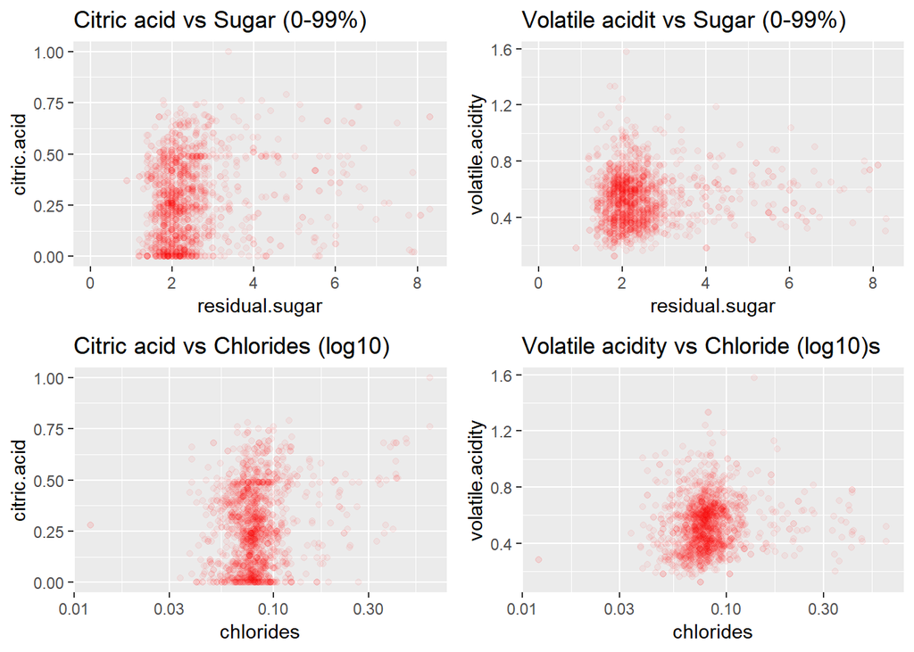

There seems to be no correlation between acids, sugar and salt

# Bivariate Analysis

### Talk about some of the relationships you observed in this part of the

investigation. How did the feature(s) of interest vary with other features in  
the dataset?

The citric acid, sulphates and alcohol has a positive correlation with the quality of wine.

### Did you observe any interesting relationships between the other features

(not the main feature(s) of interest)?

as the pH lowers the quality of wine increases, which means the wine becomes more acidic but we saw a negative correlation with volatile acids and positive for non volatile acids. this shows that the overall acidity of wine has a positive correlation with quality.

Most of the relationships are not directly linear, there is a behaviour change in relationship around level 7-8 or 3-4

### What was the strongest relationship you found?

Citric acid, volatile acid, Chlorides and sulphates are in strong relation with quality of wine

# Multivariate Plots Section

## Citric acid vs Fixed acidity and Volatile acidity on quality

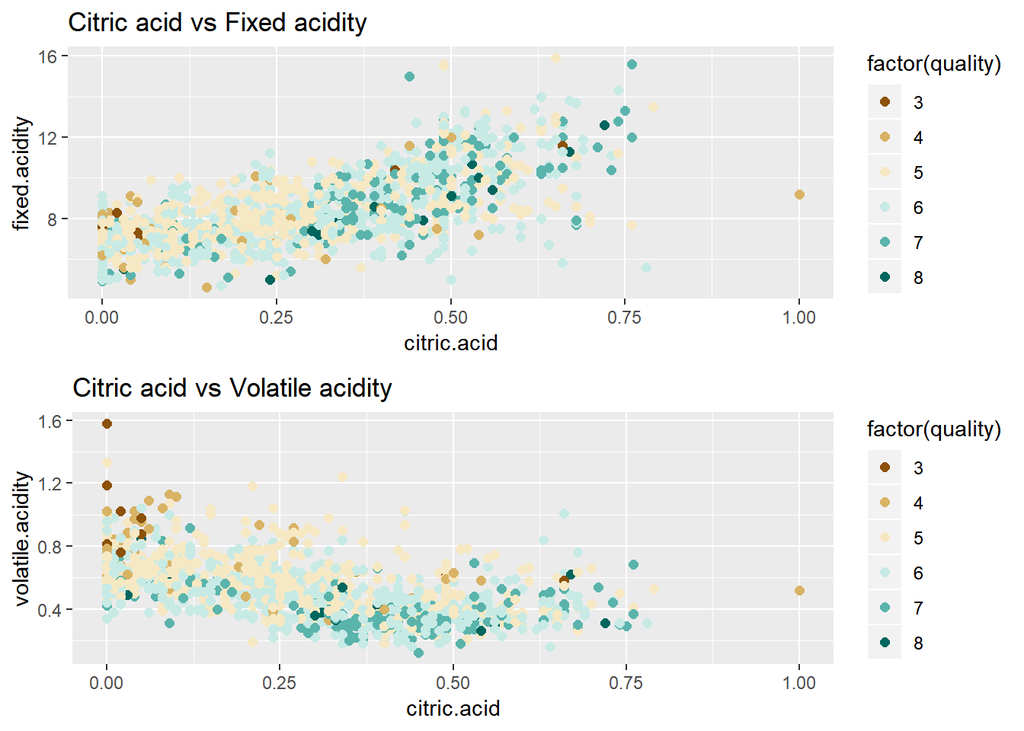

In the first graph it shows that the good quality wines have more fixed acidity and more citric acid And in second graph it shows good wines with low volatile and high cirtic acid contents

## pH vs Alcohol on Quality

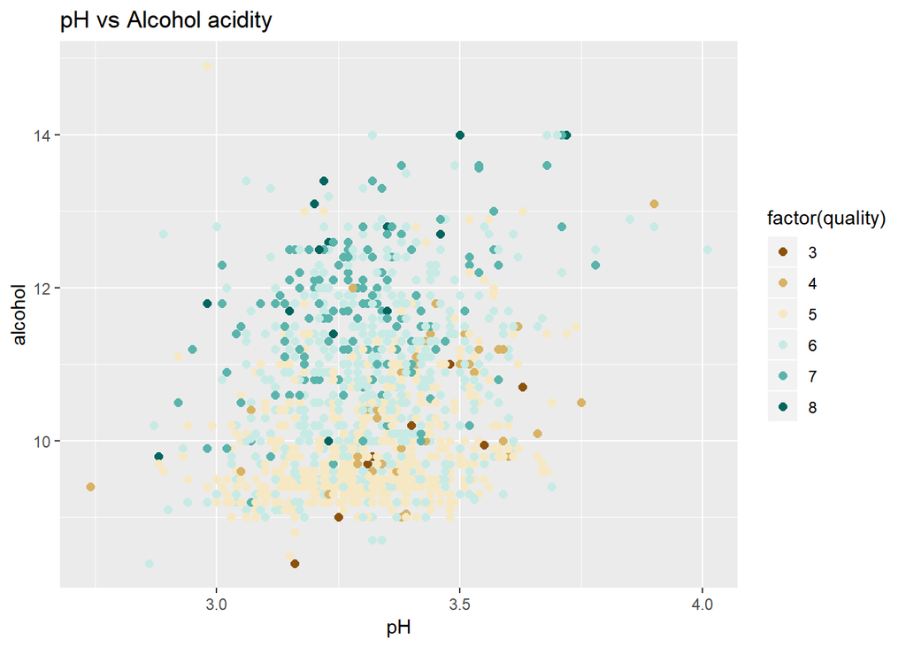

Here we see that for the same value of pH the quality of wine increases as the alcohol content increases

## Acids vs Alcohol

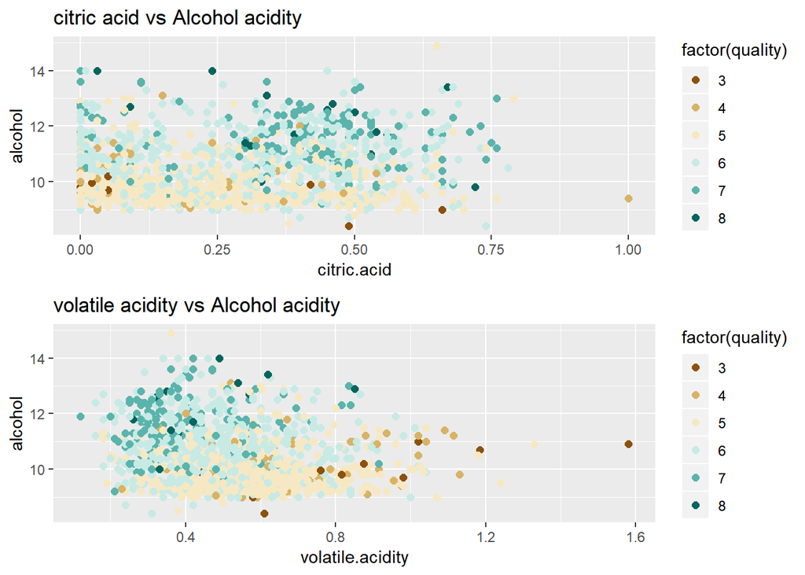

In both graphs for the same value for citric or volatile acids the quality of wine increases as alcohol content increases

## Sugar vs alcohol

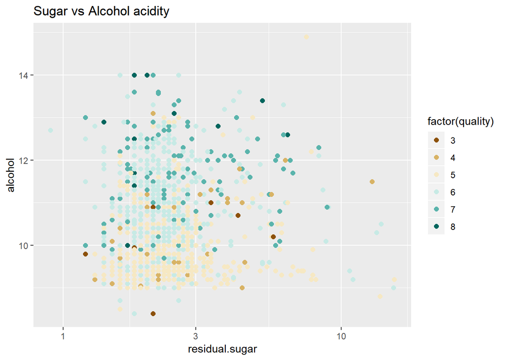

Alcohol has same relation with sugar as with acids for the quality

# Multivariate Analysis

### Talk about some of the relationships you observed in this part of the

investigation. Were there features that strengthened each other in terms of  
looking at your feature(s) of interest?

Great quality wines had high citric acid and fixed acids content and low volatile acids. And for the same pH level the alcohol has positive relation to wine quality.

### Were there any interesting or surprising interactions between features?

The alcohol content seems to have a very strong relationship with the wine quality for other variables constant the incerease in alcohol content increased the quality of wine.